# Project

Once the files are in your directory we read them

```r
training <- read.csv("pml-training.csv",header=TRUE)
testing<- read.csv("pml-testing.csv",header=TRUE)
```

Now we are going to see the data, so first i am gonna see the number of variables

```r
dim(training)
```

```
## [1] 19622   160
```

So we see that there are 160 variables now i would like to look the class of the outcome variable and the first rows and the last

```r
class(training$classe)
```

```
## [1] "character"
```

```r
head(training$classe)
```

```
## [1] "A" "A" "A" "A" "A" "A"
```

```r
tail(training$classe)
```

```
## [1] "E" "E" "E" "E" "E" "E"
```

So I see that there are at least two levels of thh data and i guess that are the letters through the A to E so i am going to transform the outcome as a factor, adn see the class the levels

```r
training$classe <- as.factor(training$classe)
class(training$classe)
```

```
## [1] "factor"
```

```r
str(training$classe)
```

```
##  Factor w/ 5 levels "A","B","C","D",..: 1 1 1 1 1 1 1 1 1 1 ...
```

Now let’s look more information about our data

```r
head(training)
str(training)
```

now looking the first rows, i can see that are a lot of columns that have Nas values and dont have values, and the columns that dont have values are character, so if i transform it to a numeric type, those columns with null values are going to fill with Nas; Now lets see how many Nas are in the columns and see if we can accept it

[output not shown]

[output cut: 10 more lines]

[output not shown]

[output not shown]

[output cut: 13 more lines]

[output not shown]

Now i see that there are a lot of variables which have a lot of missing values 19000 of 19622 is a 97% so practically this columns are empty so i have to remove them for that i will create a for loop witch is going to tell the number of the column that has empty values

```r
idx <- c()
for(i in 1:length(Nas)){
   if(Nas[i] > 19000){ idx[i] <- i}
}
idx <- idx[complete.cases(idx)]
idx
```

```
##   [1]  12  13  14  15  16  17  18  19  20  21  22  23  24  25  26  27  28  29
##  [19]  30  31  32  33  34  35  36  50  51  52  53  54  55  56  57  58  59  69
##  [37]  70  71  72  73  74  75  76  77  78  79  80  81  82  83  87  88  89  90
##  [55]  91  92  93  94  95  96  97  98  99 100 101 103 104 105 106 107 108 109
##  [73] 110 111 112 125 126 127 128 129 130 131 132 133 134 135 136 137 138 139
##  [91] 141 142 143 144 145 146 147 148 149 150
```

now with this index i can remove it from the training and test sets

```r
training <- training[,-idx]
testing <- testing[,-idx]
```

```r
training <- training[,-c(1:7)]
testing <- testing[,-c(1:7)]
dim(training)
```

```
## [1] 19622    53
```

```r
dim(testing)
```

```
## [1] 20 53
```

now i would like to use 3 the methods that were explained in the course, and see what happen so for that first i am going to look the correlation between the predictors and see if through Principal component analysis i can reduce the number of predictors

```r
M <-  abs(cor(training[,-53]))
diag(M) <- 0
which(M > 0.80, arr.ind = T)
```

```
##                  row col
## yaw_belt           3   1
## total_accel_belt   4   1
## accel_belt_y       9   1
## accel_belt_z      10   1
## accel_belt_x       8   2
## magnet_belt_x     11   2
## roll_belt          1   3
## roll_belt          1   4
## accel_belt_y       9   4
## accel_belt_z      10   4
## pitch_belt         2   8
## magnet_belt_x     11   8
## roll_belt          1   9
## total_accel_belt   4   9
## accel_belt_z      10   9
## roll_belt          1  10
## total_accel_belt   4  10
## accel_belt_y       9  10
## pitch_belt         2  11
## accel_belt_x       8  11
## gyros_arm_y       19  18
## gyros_arm_x       18  19
## magnet_arm_x      24  21
## accel_arm_x       21  24
## magnet_arm_z      26  25
## magnet_arm_y      25  26
## accel_dumbbell_x  34  28
## accel_dumbbell_z  36  29
## gyros_dumbbell_z  33  31
## gyros_forearm_z   46  31
## gyros_dumbbell_x  31  33
## gyros_forearm_z   46  33
## pitch_dumbbell    28  34
## yaw_dumbbell      29  36
## gyros_forearm_z   46  45
## gyros_dumbbell_x  31  46
## gyros_dumbbell_z  33  46
## gyros_forearm_y   45  46
```

now we can see that there are a lot of realtionships betwwen some varibles so, for that whan i train a model i will put the preprocces with pca. so now i would like to begin with the lm method or glm method, but how our outcome is a factor of a lot of levels doesn’t work, so i will try with the next methods given by the course begiing with the tree

```r
set.seed(33)
library(rpart)
library(caret)
inTrain <- createDataPartition(y=training$classe,p=0.7,list=FALSE)
train <- training[inTrain,]
test<- training[-inTrain,]

model1 <- rpart(classe ~.,data=train)
predict1 <- predict(model1,test,type="class")
confusionMatrix(predict1,test$classe)
```

```
## Confusion Matrix and Statistics
##
##           Reference
## Prediction    A    B    C    D    E
##          A 1508  242   64  140   55
##          B   52  692   76   83   96
##          C   34   86  820  144   86
##          D   29   72   61  499   44
##          E   51   47    5   98  801
##
## Overall Statistics
##
##                Accuracy : 0.7341
##                  95% CI : (0.7226, 0.7453)
##     No Information Rate : 0.2845
##     P-Value [Acc > NIR] : < 2.2e-16
##
##                   Kappa : 0.661
##
##  Mcnemar's Test P-Value : < 2.2e-16
##
## Statistics by Class:
##
##                      Class: A Class: B Class: C Class: D Class: E
## Sensitivity            0.9008   0.6076   0.7992  0.51763   0.7403
## Specificity            0.8810   0.9353   0.9280  0.95814   0.9582
## Pos Pred Value         0.7506   0.6927   0.7009  0.70780   0.7994
## Neg Pred Value         0.9572   0.9085   0.9563  0.91023   0.9425
## Prevalence             0.2845   0.1935   0.1743  0.16381   0.1839
## Detection Rate         0.2562   0.1176   0.1393  0.08479   0.1361
## Detection Prevalence   0.3414   0.1698   0.1988  0.11980   0.1703
## Balanced Accuracy      0.8909   0.7714   0.8636  0.73789   0.8492
```

```r
library(rattle)
```

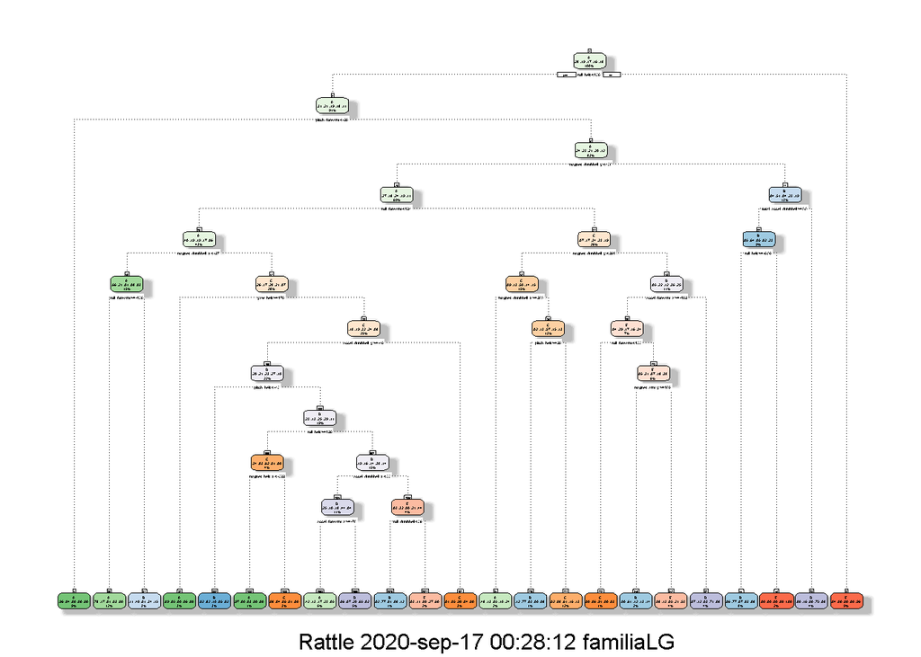

```r
fancyRpartPlot(model1)
```

now We can see that the accuracy rate of the model1 is good: 0.7341 and therefore the out-of-sample-error is about 0.2659 now let’s try with the random Forest

Note: the preProces of pca works better for regresion models, i tried pca with the tree and the accuracy was too low, without pca the accuracy works better, also with caret package the model was too slow and the accuracy too low

```r
set.seed(33)
library(randomForest)
model2 <- randomForest(x=train[,-53],y=train[,53])
predict2 <- predict(model2,test)
confusionMatrix(predict2,test$classe)
```

```
## Confusion Matrix and Statistics
##
##           Reference
## Prediction    A    B    C    D    E
##          A 1672    1    0    0    0
##          B    1 1136    7    0    0
##          C    0    2 1019   10    0
##          D    0    0    0  954    7
##          E    1    0    0    0 1075
##
## Overall Statistics
##
##                Accuracy : 0.9951
##                  95% CI : (0.9929, 0.9967)
##     No Information Rate : 0.2845
##     P-Value [Acc > NIR] : < 2.2e-16
##
##                   Kappa : 0.9938
##
##  Mcnemar's Test P-Value : NA
##
## Statistics by Class:
##
##                      Class: A Class: B Class: C Class: D Class: E
## Sensitivity            0.9988   0.9974   0.9932   0.9896   0.9935
## Specificity            0.9998   0.9983   0.9975   0.9986   0.9998
## Pos Pred Value         0.9994   0.9930   0.9884   0.9927   0.9991
## Neg Pred Value         0.9995   0.9994   0.9986   0.9980   0.9985
## Prevalence             0.2845   0.1935   0.1743   0.1638   0.1839
## Detection Rate         0.2841   0.1930   0.1732   0.1621   0.1827
## Detection Prevalence   0.2843   0.1944   0.1752   0.1633   0.1828
## Balanced Accuracy      0.9993   0.9978   0.9954   0.9941   0.9967
```

```r
library(e1071)
set.seed(33)
model3 <- naiveBayes(train$classe ~ ., data=train)
predict3 <- predict(model3,test,type = "class")
confusionMatrix(predict3, test$classe)
```

```
## Confusion Matrix and Statistics
##
##           Reference
## Prediction    A    B    C    D    E
##          A 1055  144  212   89   50
##          B   87  685  129   30  219
##          C  295  157  511  242   93
##          D  190   65   90  444  136
##          E   47   88   84  159  584
##
## Overall Statistics
##
##                Accuracy : 0.5572
##                  95% CI : (0.5444, 0.5699)
##     No Information Rate : 0.2845
##     P-Value [Acc > NIR] : < 2.2e-16
##
##                   Kappa : 0.4416
##
##  Mcnemar's Test P-Value : < 2.2e-16
##
## Statistics by Class:
##
##                      Class: A Class: B Class: C Class: D Class: E
## Sensitivity            0.6302   0.6014  0.49805  0.46058  0.53974
## Specificity            0.8825   0.9020  0.83803  0.90226  0.92130
## Pos Pred Value         0.6806   0.5957  0.39368  0.48000  0.60707
## Neg Pred Value         0.8572   0.9041  0.88773  0.89516  0.89884
## Prevalence             0.2845   0.1935  0.17434  0.16381  0.18386
## Detection Rate         0.1793   0.1164  0.08683  0.07545  0.09924
## Detection Prevalence   0.2634   0.1954  0.22056  0.15718  0.16347
## Balanced Accuracy      0.7563   0.7517  0.66804  0.68142  0.73052
```

now We can see that the accuracy rate of the model3 is medium: 0.5572 and therefore the out-of-sample-error is about 0.4428, so that means that the predictors have are not independent between them

now i would like to prove with the gbm and ida method, but the caret package is taking too long so i wont use more models. so i am gonna to select the randomForest model to response the quizz because has the high accuracy

```r
library(caret)
library(randomForest)
numFolds <- trainControl(method = "cv", number = 10)
model2 <- randomForest(x=train[,-53],y=train[,53],trControl=numFolds)
predict2 <- predict(model2,test)
confusionMatrix(predict2,test$classe)
```

```
## Confusion Matrix and Statistics
##
##           Reference
## Prediction    A    B    C    D    E
##          A 1672    1    0    0    0
##          B    1 1136    7    0    0
##          C    0    2 1019   10    0
##          D    0    0    0  954    7
##          E    1    0    0    0 1075
##
## Overall Statistics
##
##                Accuracy : 0.9951
##                  95% CI : (0.9929, 0.9967)
##     No Information Rate : 0.2845
##     P-Value [Acc > NIR] : < 2.2e-16
##
##                   Kappa : 0.9938
##
##  Mcnemar's Test P-Value : NA
##
## Statistics by Class:
##
##                      Class: A Class: B Class: C Class: D Class: E
## Sensitivity            0.9988   0.9974   0.9932   0.9896   0.9935
## Specificity            0.9998   0.9983   0.9975   0.9986   0.9998
## Pos Pred Value         0.9994   0.9930   0.9884   0.9927   0.9991
## Neg Pred Value         0.9995   0.9994   0.9986   0.9980   0.9985
## Prevalence             0.2845   0.1935   0.1743   0.1638   0.1839
## Detection Rate         0.2841   0.1930   0.1732   0.1621   0.1827
## Detection Prevalence   0.2843   0.1944   0.1752   0.1633   0.1828
## Balanced Accuracy      0.9993   0.9978   0.9954   0.9941   0.9967
```

```r
lastQuizz<- predict(model2, testing)
lastQuizz
```

```
##  1  2  3  4  5  6  7  8  9 10 11 12 13 14 15 16 17 18 19 20
##  B  A  B  A  A  E  D  B  A  A  B  C  B  A  E  E  A  B  B  B
## Levels: A B C D E
```